# Project: Investigate a Dataset (Soccer database)

- Introduction
- Data Wrangling
- Exploratory Data Analysis
- Conclusions

## Introduction

> In this project I'm going to explore the dataset soccer database. This database is a relational database that holds data about teams, teams attributes as well as matches theses teams played over seasons in tables.

### Posed Questions:

> 1. What is the best body weight for a player to have high stamina and speed?
> 2. How to determine if a player is a defender or attacker based on player attributes?

```python
import pandas as pd
import numpy as np
from sqlalchemy import create_engine
import matplotlib.pyplot as plt
import seaborn as sns
%matplotlib inline
```

## Data Wrangling

### General Properties

> First let's load dataframes from sqllite database into dataframes and assess them.

```python
database_engine = create_engine("sqlite:///C:\\Users\\Mohammed salama\\Music\\data analysis project\\archive\\database.sqlite")
players_attributes = pd.read_sql("SELECT * FROM Player_Attributes" , database_engine , index_col= 'id')
players_attributes.info()
```

```
<class 'pandas.core.frame.DataFrame'>
Int64Index: 183978 entries, 1 to 183978
Data columns (total 41 columns):
 #   Column               Non-Null Count   Dtype
---  ------               --------------   -----
 0   player_fifa_api_id   183978 non-null  int64
 1   player_api_id        183978 non-null  int64
 2   date                 183978 non-null  object
 3   overall_rating       183142 non-null  float64
 4   potential            183142 non-null  float64
 5   preferred_foot       183142 non-null  object
 6   attacking_work_rate  180748 non-null  object
 7   defensive_work_rate  183142 non-null  object
 8   crossing             183142 non-null  float64
 9   finishing            183142 non-null  float64
```

[output cut: 33 more lines]

```python
pd.set_option("display.max_columns", None)
players_attributes.head()
```

| id | player_fifa_api_id | player_api_id | date | overall_rating | potential | preferred_foot | attacking_work_rate | defensive_work_rate | crossing | finishing | heading_accuracy | short_passing | volleys | dribbling | curve | free_kick_accuracy | long_passing | ball_control | acceleration | sprint_speed | agility | reactions | balance | shot_power | jumping | stamina | strength | long_shots | aggression | … |
| --- | --- | --- | --- | --- | --- | --- | --- | --- | --- | --- | --- | --- | --- | --- | --- | --- | --- | --- | --- | --- | --- | --- | --- | --- | --- | --- | --- | --- | --- | --- |
| 1 | 218353 | 505942 | 2016-02-18 00:00:00 | 67.0 | 71.0 | right | medium | medium | 49.0 | 44.0 | 71.0 | 61.0 | 44.0 | 51.0 | 45.0 | 39.0 | 64.0 | 49.0 | 60.0 | 64.0 | 59.0 | 47.0 | 65.0 | 55.0 | 58.0 | 54.0 | 76.0 | 35.0 | 71.0 | … |
| 2 | 218353 | 505942 | 2015-11-19 00:00:00 | 67.0 | 71.0 | right | medium | medium | 49.0 | 44.0 | 71.0 | 61.0 | 44.0 | 51.0 | 45.0 | 39.0 | 64.0 | 49.0 | 60.0 | 64.0 | 59.0 | 47.0 | 65.0 | 55.0 | 58.0 | 54.0 | 76.0 | 35.0 | 71.0 | … |
| 3 | 218353 | 505942 | 2015-09-21 00:00:00 | 62.0 | 66.0 | right | medium | medium | 49.0 | 44.0 | 71.0 | 61.0 | 44.0 | 51.0 | 45.0 | 39.0 | 64.0 | 49.0 | 60.0 | 64.0 | 59.0 | 47.0 | 65.0 | 55.0 | 58.0 | 54.0 | 76.0 | 35.0 | 63.0 | … |
| 4 | 218353 | 505942 | 2015-03-20 00:00:00 | 61.0 | 65.0 | right | medium | medium | 48.0 | 43.0 | 70.0 | 60.0 | 43.0 | 50.0 | 44.0 | 38.0 | 63.0 | 48.0 | 60.0 | 64.0 | 59.0 | 46.0 | 65.0 | 54.0 | 58.0 | 54.0 | 76.0 | 34.0 | 62.0 | … |
| 5 | 218353 | 505942 | 2007-02-22 00:00:00 | 61.0 | 65.0 | right | medium | medium | 48.0 | 43.0 | 70.0 | 60.0 | 43.0 | 50.0 | 44.0 | 38.0 | 63.0 | 48.0 | 60.0 | 64.0 | 59.0 | 46.0 | 65.0 | 54.0 | 58.0 | 54.0 | 76.0 | 34.0 | 62.0 | … |

```python
players = pd.read_sql("SELECT * FROM Player" , database_engine , index_col= 'id')
players.info()
```

```
<class 'pandas.core.frame.DataFrame'>
Int64Index: 11060 entries, 1 to 11075
Data columns (total 6 columns):
 #   Column              Non-Null Count  Dtype
---  ------              --------------  -----
 0   player_api_id       11060 non-null  int64
 1   player_name         11060 non-null  object
 2   player_fifa_api_id  11060 non-null  int64
 3   birthday            11060 non-null  object
 4   height              11060 non-null  float64
 5   weight              11060 non-null  int64
dtypes: float64(1), int64(3), object(2)
memory usage: 604.8+ KB
```

```python
players.head()
```

| id | player_api_id | player_name | player_fifa_api_id | birthday | height | weight |
| --- | --- | --- | --- | --- | --- | --- |
| 1 | 505942 | Aaron Appindangoye | 218353 | 1992-02-29 00:00:00 | 182.88 | 187 |
| 2 | 155782 | Aaron Cresswell | 189615 | 1989-12-15 00:00:00 | 170.18 | 146 |
| 3 | 162549 | Aaron Doran | 186170 | 1991-05-13 00:00:00 | 170.18 | 163 |
| 4 | 30572 | Aaron Galindo | 140161 | 1982-05-08 00:00:00 | 182.88 | 198 |
| 5 | 23780 | Aaron Hughes | 17725 | 1979-11-08 00:00:00 | 182.88 | 154 |

### Data Cleaning

fill null values in player attributes with average values for each column.

```python
means = players_attributes.mean()
players_attributes.fillna(means , inplace= True)
```

Cast datatype of date column from str to datetime type. drop duplicates.

```python
players_attributes['date'] = pd.to_datetime(players_attributes['date'])
players_attributes.drop_duplicates(inplace= True)
players_attributes.info()
```

```
<class 'pandas.core.frame.DataFrame'>
Int64Index: 183977 entries, 1 to 183978
Data columns (total 41 columns):
 #   Column               Non-Null Count   Dtype
---  ------               --------------   -----
 0   player_fifa_api_id   183977 non-null  int64
 1   player_api_id        183977 non-null  int64
 2   date                 183977 non-null  datetime64[ns]
 3   overall_rating       183977 non-null  float64
 4   potential            183977 non-null  float64
 5   preferred_foot       183142 non-null  object
 6   attacking_work_rate  180748 non-null  object
 7   defensive_work_rate  183142 non-null  object
 8   crossing             183977 non-null  float64
 9   finishing            183977 non-null  float64
```

[output cut: 33 more lines]

```python
players.drop_duplicates(inplace= True)
players['birthday'] = pd.to_datetime(players['birthday'])
```

```python
players.info()
```

```
<class 'pandas.core.frame.DataFrame'>
Int64Index: 11060 entries, 1 to 11075
Data columns (total 6 columns):
 #   Column              Non-Null Count  Dtype
---  ------              --------------  -----
 0   player_api_id       11060 non-null  int64
 1   player_name         11060 non-null  object
 2   player_fifa_api_id  11060 non-null  int64
 3   birthday            11060 non-null  datetime64[ns]
 4   height              11060 non-null  float64
 5   weight              11060 non-null  int64
dtypes: datetime64[ns](1), float64(1), int64(3), object(1)
memory usage: 604.8+ KB
```

## Exploratory Data Analysis

### Research Question 1 (Does the body weight affects sprint speed and stamina for a player?)

Merge players dataframe with players attributes on player_api_id column.

```python
dataframe = pd.merge(players[['player_api_id','weight']] , players_attributes[['player_api_id','stamina','balance','sprint_speed','strength','short_passing','standing_tackle','dribbling','ball_control','shot_power','long_passing','vision','defensive_work_rate','attacking_work_rate']], on= ['player_api_id'])
dataframe.head()
```

|  | player_api_id | weight | stamina | balance | sprint_speed | strength | short_passing | standing_tackle | dribbling | ball_control | shot_power | long_passing | vision | defensive_work_rate | attacking_work_rate |
| --- | --- | --- | --- | --- | --- | --- | --- | --- | --- | --- | --- | --- | --- | --- | --- |
| 0 | 505942 | 187 | 54.0 | 65.0 | 64.0 | 76.0 | 61.0 | 69.0 | 51.0 | 49.0 | 55.0 | 64.0 | 54.0 | medium | medium |
| 1 | 505942 | 187 | 54.0 | 65.0 | 64.0 | 76.0 | 61.0 | 69.0 | 51.0 | 49.0 | 55.0 | 64.0 | 54.0 | medium | medium |
| 2 | 505942 | 187 | 54.0 | 65.0 | 64.0 | 76.0 | 61.0 | 66.0 | 51.0 | 49.0 | 55.0 | 64.0 | 54.0 | medium | medium |
| 3 | 505942 | 187 | 54.0 | 65.0 | 64.0 | 76.0 | 60.0 | 63.0 | 50.0 | 48.0 | 54.0 | 63.0 | 53.0 | medium | medium |
| 4 | 505942 | 187 | 54.0 | 65.0 | 64.0 | 76.0 | 60.0 | 63.0 | 50.0 | 48.0 | 54.0 | 63.0 | 53.0 | medium | medium |

Aggregate data based on the average recorded attributes values over years.

```python
dataframe__= dataframe.groupby('player_api_id', as_index= False).mean()
```

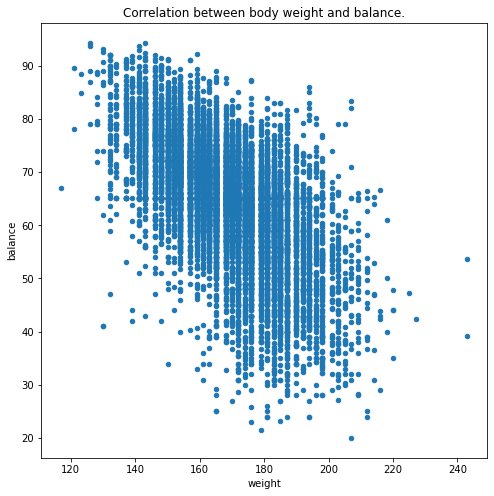

```python
dataframe__.plot(x= "weight", y= "balance", kind= "scatter", figsize= (8,8), title= "Correlation between body weight and balance.")
```

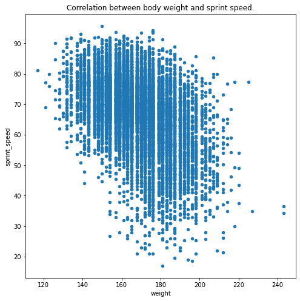

```python
dataframe__.plot(x= "weight", y= "sprint_speed",kind= "scatter", figsize= (8,8), title= "Correlation between body weight and sprint speed.")
```

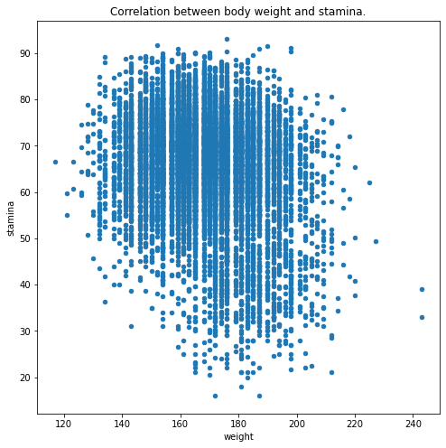

```python
dataframe__.plot(x= "weight", y= "stamina", kind= "scatter", figsize= (8,8), title= "Correlation between body weight and stamina.")
```

### Research Question 2 (How to determine if a player is a defender or attacker based on player attributes?)

Determine if a player is a defender or an attacker. I will drop players that arn't neither defenders nor attackers.

```python
def classify_player( row ):
    if row['defensive_work_rate'] == 'high':
        return 'defender'
    elif row['attacking_work_rate'] == 'high':
        return 'attacker'
    else:
        return 'no'
dataframe['category'] = dataframe.apply( classify_player, axis= 1 )
```

```python
dataframe = dataframe.drop(dataframe[dataframe['category'] == 'no'].index)
```

Drop player_api_id column from my dataframe because it's not needed for answering the second question.

```python
dataframe.drop(columns= dataframe[['player_api_id','defensive_work_rate','attacking_work_rate','weight']],inplace= True)
```

Calculate the average value for each player attribute for all defender and attacker players in the dataset.

```python
dataframe_= dataframe.groupby(['category'], as_index= True).mean()
```

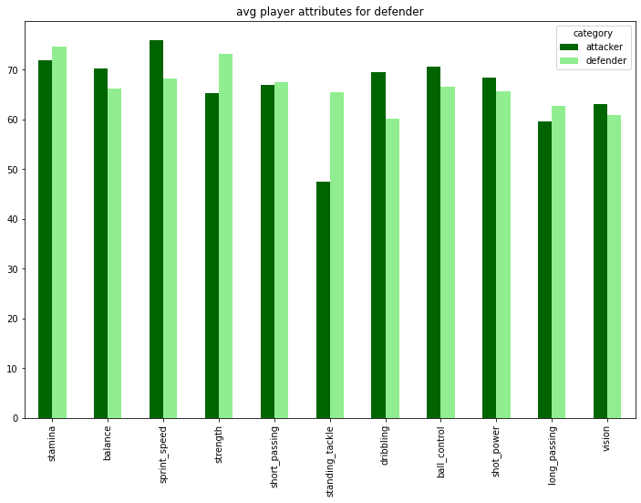

```python
dataframe_.transpose().plot(kind= "bar", figsize= (12,8), title= "avg player attributes for defender", color= ['darkgreen','lightgreen'])
```

## Conclusions

> 1. As body weight increases for a player the balance and sprint speed decreases in general.
> 2. Body weight doesn't have a significant effect on stamina for a player.
> 3. On average, attacker players are higher in balance, sprint speed, dribbling, ball control shot power and vision.
> 4. On average, defender players are higher in stamina, strength, standing tackle and long pass.